# Homework Assignment 1

Nathan Gendich

Assigned: Oct 24, 2020, Due Sun Nov 01, 2020 11:59PM

## HW-1 Instructions

> Our class emphasizes clear communication of data analysis results to non-technical audiences. I expect your HTML output documents to be readable and well formatted. I expect you to put ample comments in your R code to make the code understandable. Along with accuracy of results, I am looking for quality of presentation as well. This homework is due by **11:59PM on Nov 01st**. To complete this assignment, follow these steps:
1. Create a new RStudio Project for this HW. Sync the project directory with a GitHub Repository (see instructions on Canvas on how to do that).
2. Download the `HW1.Rmd` file from Canvas. Save the file in the RStudio Project Directory.
3. Open `HW1.Rmd` in RStudio. Replace the “Your Name Here” text in the `author:` field with your name.
4. Supply your solutions to the homework by editing `HW1.Rmd`.
5. Run your code in the Console and Knit HTML frequently to check for errors.
6. You may find it easier to solve a problem by interacting only with the Console at first.
7. When you have completed the homework please check that your knits correctly when you click `Knit HTML`.
8. “Push” all your local changes to the GitHub Repo for the project.
9. Submit your RMD file, the HTML output and a link to your GitHub Repo on Canvas.

## Data frame basics

We will continue working with the nycflights dataset we looked at in class. **Please be sure to keep the data file in the same directory as the RMD file - your project directory.**

First - make sure that you are reading the data correctly and doing all the data cleaning steps that we did in class. Feel free to go beyond our class work in cleaning the data if you feel the need.

```r
nyc <- read.csv("nycflights.csv")
nyc$X <- NULL
nyc$carrier <- as.factor(nyc$carrier)
nyc$flight <- as.factor(nyc$flight)
nyc$tailnum <- as.factor(nyc$tailnum)
nyc$origin <- as.factor(nyc$origin)
nyc$dest <- as.factor(nyc$dest)
```

I now would like you to answer the following - all in their own separate R code blocks.

### Data Exploration

Let’s first do some simple exploration of this data. I would like for you to answer each of the questions below with an **inline R code** integrated into the text and not in a separate R code block.

- How many airlines are there? (Hint: `levels` and `length` can be useful here)

There are 16 airlines.

- How many flights there were by the airline with code `OO`? (Hint: `nrow` can be useful here along with logical indexing)

There are 32 flights with code “OO”.

- How long is the shortest flight out of any NYC airport? (Hint: `min` can be useful, remember to handle `NA` values)

The shortest flight out of any NYC airport is 20 minutes.

- How many flights where there by United Airlines (code: UA) on Jan 12th 2013?

There were 112 flights by UA on Jan 12 2013.

### Arrival Delay

Lets focus on Arrival Delay.

- What was the average arrival delay for all airports and all airlines combined in Jan 2013?

The average arrival delay is 6.13 minutes.

- Whats was the median arrival delay for all airports and all airlines combined in Jan 2013?

The median arrival delay is -3 minutes.

Based on your answers to the two questions above, what can you say about the distribution of arrival delays? Provide your answer in a text paragraph form.

- You can tell that the distribution is skewed right since the mean is larger than the median. It is not a symmetrical distribution.

### Airline Performance

Lets see if all airlines are equally terrible as far as flight arrival delays are concerned. For this question you will have to make sure that airline column is coded as a factor.

- Calculate average arrival delays by airline (Hint: look up the command `tapply`)

```r
AvgArrDelay <- tapply(nyc$arr_delay, nyc$carrier, mean, na.rm = TRUE)
round(AvgArrDelay, 2)
```

```
##    9E    AA    AS    B6    DL    EV    F9    FL    HA    MQ    OO    UA    US
##  7.38  0.36 -9.93  9.46  1.64 15.80 21.92 20.12 -6.92 10.77 11.93  3.56  2.13
##    VX    WN    YV
##  1.76  9.65 15.56
```

- Draw a Bar Plot of Average Arrival Delays for all the Airlines (Hint: command for making a Bar Plot is simply `barplot`)

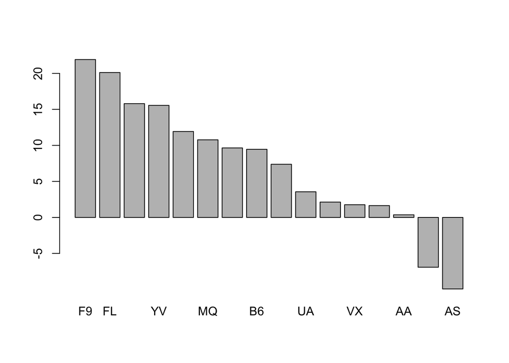

```r
barplot(sort(AvgArrDelay, decreasing = TRUE))
```

- Which airline has the highest average arrival delay? Which airline has the smallest average arrival delay? Are there airlines that actually have negative average delay? Provide answer to this question in a text paragraph form using **inline R code**.

The airline with the highest average arrival delay is F9. The airline with the smallest average arrival delay is AS. The airlines with negative average arrival delays are AS, HA.

### Air Gain

Create a new column named airgain such that airgain = (departure delay - arrival delay) : this is the amount of delay a flight made up while in air.

```r
nyc$airgain <- nyc$dep_delay - nyc$arr_delay
```

1. Explore airgain data - calculate suitable descriptive statistics and appropriate graphics to better understand this data. This part is open ended - you do what you feel works best for you.

The average airgain is 5.6597789 minutes.

The median airgain is 7 minutes.

The standard deviation of airgain is 18.0436483.

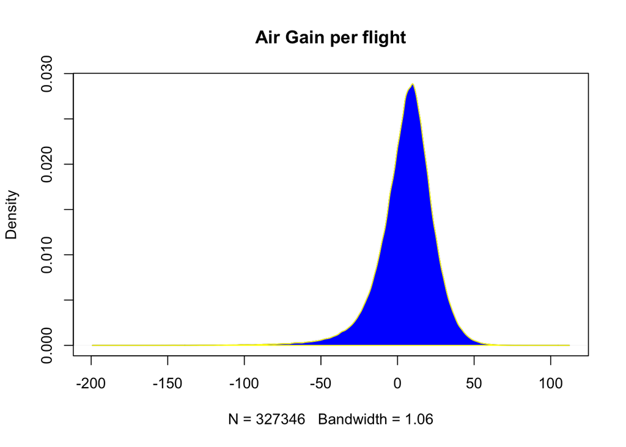

```r
# Density Plot
d <- density(nyc$airgain, na.rm = TRUE)
plot(d, main="Air Gain per flight")
polygon(d, col="blue", border="yellow")
```

- I couldn’t figure out how to add a mean line to this density plot, but I would like to learn.
2. Answer the questions:
- do airlines actually gain any time when in air on average?

Airlines gain an average of 5.66 minutes per flight.

- Calculate average airgain for different airlines - which airlines do a better job, which do a worse job?

```r
AvgAirGain <- tapply(nyc$airgain, nyc$carrier, mean, na.rm = TRUE)
AirGainDec <- sort(round(AvgAirGain, 2), decreasing = TRUE)
AirGainDec
```

```
##    AS    HA    VX    9E    UA    AA    WN    DL    EV    B6    YV    US    OO
## 15.76 11.82 10.99  9.06  8.46  8.20  8.01  7.58  4.04  3.51  3.34  1.62  0.66
##    MQ    FL    F9
## -0.33 -1.51 -1.72
```

The airlines AS, HA, VX do a good job of gaining time in the air, at least 10 minutes on average. The airlines MQ, FL, F9 lose time in the air however.

- Build a graphic of average airgain for different airlines sorted by airgain. We want to graphically visualize which airlines are good at “catching up” when in air and which airlines actually lose time further after taking off.

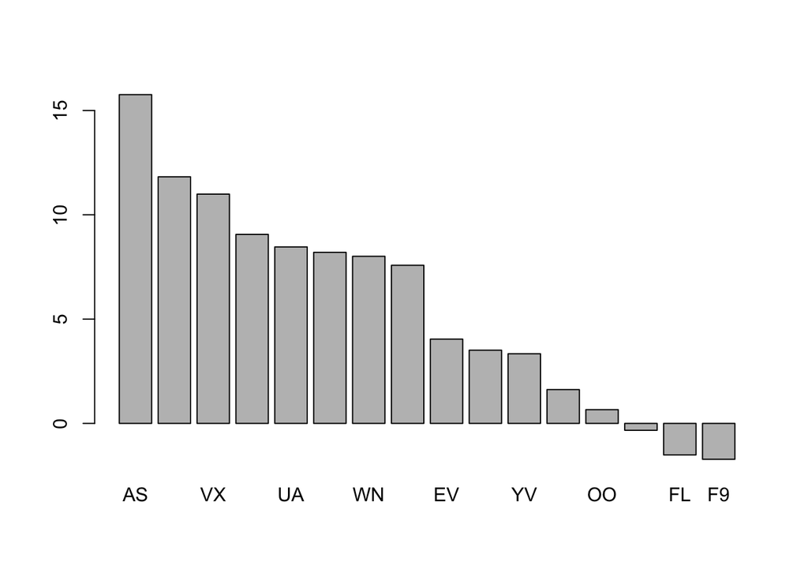

```r
barplot(AirGainDec)
```

That’s it. Once you are done, make sure everything works and knits well and then you can push your changes to the GitHub repo and uplaod the RMD flile and the html output to Canvas.

**Have Fun!**

Sanjeev